# Projecting the public health, economic and educational benefits of CEPI’s 100 day mission with the DAEDALUS model

22 May, 2024

# 1 Aim

The objective of the proposed work is to use scenario modelling to help ascertain the value of current CEPI investments into the development and distribution of a vaccine 100 days after identification of a new SARS virus (SARS-X) with pandemic potential. In addition, we will estimate the value of a broadly protective sarbecovirus vaccine (BPSV) that would be available prior to the development of the SARS-X–specific vaccine. The analysis scope is to run three new SARS-X health, economic and education impacts scenarios (both for SARS-X 100-day mission and BPSV+SARS-X 100-day mission options) allowing for variations in preparedness and epidemiological parameters (to be discussed). We will will estimate the value of investments for different country types in monetary terms across three dimensions of societal welfare, combining economic losses due to business closures and lost education, and lives lost:

- Health: Live-years saved, monetised using the value of a statistical life (VSL);
- GDP: Gain to short-term economic output from reduced economic closures and disruptions to demand and labour supply;
- Education: long-term economic gains of reduced length and severity of closures of educational institutions.

We will simulate hypothetical pandemics caused by a SARS virus with a disease profile informed by past epidemics. We will use the integrated epi-econ model DAEDALUS developed in our group for estimating the benefit of pandemic preparedness (P2) (Haw et al. 2022). We will construct three representative hypothetical countries (low- and lower-middle income, upper-middle income, and high income) using real-world demographic, societal and economic data from 197 countries. Within those, we will construct two types of epidemic: those that emerge within the country (which we label “origin”), and those imported from outside (which we label “secondary”). The nature and stringency of non-pharmaceutical mitigation interventions (NPIs) implemented by policy makers once the emergency strikes is an important unknown that will determine benefits of vaccinations. We will therefore evaluate outcomes for four alternative mitigation strategies (“unmitigated,” “adaptive economic closures,” “school closures,” and “elimination”) for each vaccination scenario. The faster vaccines control infections, the earlier NPIs can be relaxed. The reduced need for stringent NPIs constitutes the benefit of the 100 day-mission. However, the types of benefit that countries enjoy depend on the chosen NPI. For example, for an unmitigated policy, significant benefits accrue in terms of deaths averted; for adaptive economic closures, significant benefits accrue in terms of economic gains. It is unknown what NPIs countries will choose for future emergencies. We select the cost-minimising policy for each country type and income level, assuming that the policy makers’ aim is to maximize societal welfare.

We will estimate the value of the programme to each country group as the difference in total societal costs between scenarios with and without accelerated availability of both a SARS-X–specific vaccine and a BPSV.

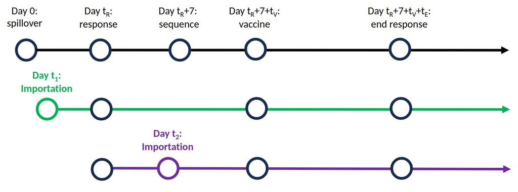

Schematic view of the timeline of a pandemic. At time 0 a new SARS pathogen emerges. At time $t_R$ the pathogen is identified following a number of hospitalisations. A pandemic is declared. Genomic sequencing begins. Governments may implement non-pharmaceutical interventions. A broadly protective Sarbecovirus vaccine (BPSV) is rolled out in all places to people aged 65 and over. At time $t_R+7$ the pathogen is sequenced. Vaccine R&D begins. At time $t_R+7+t_V$ a vaccine specific to the new pathogen is rolled out in all places to people aged 15 and over. $t_V$ is 365 in the BAU scenario and 100 in the 100-day vaccine scenario. At time $t_R+7+t_V+t_E$ vaccine rollout completes. All non-pharmaceutical interventions cease. $t_E$ is 160 times the fraction of the population who are aged 15 and over. At time $t_i$ the pathogen is imported into country $i$. $t_i=0$ for a country in which a spillover event occurs.

# 2 Modelling framework

We will use an extensive modelling framework for COVID-19 that has been developed by our team over the last 3 years, the integrated economic–epidemiological model DAEDALUS (Haw et al. 2022). It is described briefly below and in more detail in the cited publications. The model has been developed in an open-access framework with all code available on Github. The model has been continuously updated throughout the pandemic as our understanding of SARS-CoV-2 transmission and the impact of vaccination has evolved, and is being further updated currently to model other hypothetical respiratory pandemics to answer questions on pandemic preparedness.

## 2.1 The integrated economic-epidemiological model

The epidemiological component of the DAEDALUS model consists of seven disease states (susceptible, exposed, asymptomatic infectious, symptomatic infectious, hospitalised, recovered, and died), in triplicate to represent vaccination states. The population is stratified by age (into four age groups: infants, adolescents, working-age adults, and retirement-age adults). The working-age adults are further stratified by sector of work (into 46 groups: 45 sectors according to the OECD classification, and one non-working group). We will use epidemiological parameters expected of a future SARS pandemic, where we use past respiratory pandemics to inform our expectations. Epidemiologically relevant demographic parameters, such as mixing matrices, will be drawn from published estimates (Jarvis et al. 2023; Walker et al. 2020). As far as possible, parameters, assumptions and modelling approaches will be closely aligned with Imperial’s SARS-X model that is being developed by Prof Azra Ghani and team for Stage 2 of the technical work for CEPI.

The economic model takes as input the pre-pandemic Gross Value Added (GVA) per sector of countries, which uses the OECD classification of 45 economic sectors. Both models further take as input the observed economic configurations over 2020. These are the observed combinations of sector closures, i.e. the extent to which each sector was open in each period (month or quarter). This depends on the chosen mitigation policy. All economic configuration profiles will be based on sectoral GVA profiles observed in 2020 (OECD), where the monthly GVA of a sector relative to its value one year prior is interpreted as the degree to which it was open.

A sector is open to a maximum amount of 100%, when its full monthly pre-pandemic GVA value is realised. If a sector is open to 50%, it contributes 50% of its maximum GVA for that period. Sector closures describe the extent of reduction of contacts (and disease transmission) among and between workers and consumers. In the epidemic model, contacts associated with a partially closed sector are scaled down. Observed economic configurations, i.e. sector closures, capture also changes in demand and supply due to infection avoidance of individuals and interruptions in supply chains; we do not attempt to disentangle these from mandated closures.

## 2.2 Mitigation strategies

We will model four mitigation strategies that decision maker may adopt once the novel pathogen has been identified. These are “unmitigated,” “adaptive economic closures,” “school closures,” and “elimination.” The policy defines government-mandated actions. In addition, we model behaviour changes in response to case numbers that impact on transmission. - Unmitigated: no aversive actions are taken. - Economic closures: sectors close to a pre-specified economic configuration when hospital occupancy approaches its capacity, and open again once infections have reduced sufficiently. - School closures: schools remain closed at 10% and other economic sectors open and close reactively, as in Economic closures. - Elimination: stringent economic closures are maintained until case numbers can be contained by a testing programme. We will designate the policy that minimises costs across health, GDP and education to be the mitigation choice for each country type and income level and vaccination scenario.

## 2.3 Countries

We will consider three stylised “countries” and parameterise models using data from constituent countries according to the World Bank income-classification categories:

- LLMIC, using inputs from LICs and LMICs
- UMIC, using inputs UMICs
- HIC, using inputs from HICs

We will generate a distribution over outcomes through sampling inputs. This distribution represents a catalogue of synthetic countries whose characteristics are randomly taken from candidate countries. We will include uncertainty in as many parameters as possible. We will sample from specified distributions, or sample with replacement from a discrete set of candidate options, where the candidate options are the values belonging to countries in the income group. We will weigh parameter values according to population sizes of all countries, giving those parameter values greater importance that originate from larger countries.

## 2.4 Vaccination scenarios

Vaccination scenarios will be encoded via the parameters for vaccine effects, the time that vaccination begins, the rate of vaccine administration, and uptake among the population. The baseline scenario will mimic vaccination as observed in the COVID-19 pandemic, with all parameters taken from observations in 2020 and 2021. The 100-day vaccine scenario will assume a vaccine-effect profile similar to those of mRNA COVID-19 vaccines, and that vaccination begins 100 days after SARS-X is sequenced, with alternative administration rate and uptake explored in sensitivity analyses. The BPSV scenario will assume that the 100-day vaccine events will occur, and that, prior to that, the BPSV will be available, with effect parameters more similar to those of an influenza vaccine, with vaccination beginning at the time of identification of the SARS-X virus, and with alternative administration rate and uptake explored in sensitivity analyses.

**TO DO: baseline scenario will be the same as the 100-day scenario, except it will be 365 days. This is approximately when the first COVID-19 vaccines were administered. The scenarios will be aligned on assumptions but the baseline scenario will not be aligned with reality: we will be underestimating the benefits to lower-income countries who were later in obtaining vaccines.**

**TO DO: create a new scenario with the BPSV and the 365-day vaccine. Compare all three vaccine scenarios to the BAU scenario.**

## 2.5 Valuations

The outcomes of the DAEDALUS model are:

1. Health: Live-years lost globally and by country income groups;
2. GDP: Short-term economic loss from economic closures and disruptions to demand and labour supply, globally, by country income groups, and by economic sectors;
3. Education: long-term economic loss from closures of educational institutions, globally and by country income groups.

Numbers of deaths are translated into discounted years of life lost (dYLL). This takes into account the life expectancy of each person who dies. dYLLs are valued using the value of a statistical life, which we estimate as being 160 times GDP per capita (Robinson, Hammitt, and O’Keeffe 2019).

GDP loss is estimated as the total GDP - the sum of GVA across all sectors, scaled by how open they are across the year - divided by the value of GDP when all sectors are completely open all the time.

Education loss takes into account the extent to which schools are closed, as well as the effectiveness of remote learning. Education loss is valued by taking into consideration life-long earning losses, following (Psacharopoulos, Collis, and Patrinos 2021).

Taken together, these form the societal cost (SC) of the epidemic in the country, expressed as a percentage of GDP (for the year prior to the pandemic). For each scenario and each country type and income level, we will assume that the social planner chooses the mitigation policy that minimises the expected SC – call it the minimum expected SC, or MESC. The value of the 100-day vaccine in each country type and income level will be the MESC of the 100-day vaccine scenario minus the MESC of the baseline scenario. Similarly, the value of the BPSV in each country type and income level will be the MESC of the BPSV scenario minus the MESC of the 100-day vaccine scenario.

## 2.6 Value of information

We use value-of-information methods to quantify relationships between inputs and outputs. Specifically, we estimate the expected value of partial perfect information (EVPPI), which is the expected gain (in terms of reduction of uncertainty in the outcome) of knowing a parameter (or set of parameters) perfectly (Jackson et al. 2021). Equivalently, and in terms of identifying indicators of vulnerability, it tells us which parameters best predict the outcome.

Value of information is a decision-theoretic quantity. We estimate it using the R package **voi**. Intuitively, EVPPI functions in a similar way to correlation. In the case of a linear relationship between one input and one output, the computation of EVPPI is essentially the same as that of a correlation. EVPPI extends a simple correlation analysis in two ways relevant to the results presented: 1) nonlinear relationships are also captured, and 2) we can assess the EVPPI of a set of parameters. EVPPI allows us to identify influential parameters. Once identified, relationships between the influential parameter (sets) and outcomes need to be examined independently in order to understand the nature of the relationship.

## 2.7 Scenario levels

Previously:

| **Variable** | **Levels** | **Description** |
| --- | --- | --- |
| **Income level** | HIC | High-income countries |
|  | UMIC | Upper-middle–income countries |
|  | LLMIC | Low- and lower-middle–income countries |
| **Mitigation policy** | No closures | Unmitigated pandemic |
|  | School closures | Schools close reactively |
|  | Economic closures | Sectors close reactively |
|  | Elimination | Contain by testing |
| **Country type** | Origin | Where the outbreak begins |
|  | Secondary | To where cases are exported |
| **Vaccination** | BAU | Business as usual |
|  | 100 day | SARS-X vaccine available after 100 days |
|  | BPSV | Broadly protective sarbecovirus vaccine |

Proposed:

| **Variable** | **Levels** | **Description** |
| --- | --- | --- |
| **Income level** | HIC | High-income countries |
|  | UMIC | Upper-middle–income countries |
|  | LLMIC | Low- and lower-middle–income countries |
| **Mitigation policy** | No closures | Unmitigated pandemic |
|  | School closures | Schools close reactively |
|  | Economic closures | Sectors close reactively |
|  | Elimination | Contain by testing |
| **BPSV** | No | There is no BPSV stockpile |
|  | Yes | Stockpiled BPSV rolled out to 65+ |
| **SARS-X–specific vaccine** | 365 | SARS-X vaccine available 365 days after sequencing |
|  | 100 | SARS-X vaccine available 100 days after sequencing |

## 2.8 Fixed parameters

| Parameter | Value |
| --- | --- |
| Maximum R$_0$ | 4 |
| Vaccines given per day | 0.5% of population |
| Final vaccine coverage | 80% of people aged 15+ |

# 3 Results

We first present results on the outcomes or costs of pandemics for the analysed scenarios, in total and separately by the three types of outcomes. We then present the estimated values of the vaccine scenarios that arise by computing the reduction in costs associated with vaccination.

## 3.1 Distributions over outcomes

Table 3.1: Results for all vaccination levels, scenarios and country types. Mean values and 95% prediction intervals.

| Scenario | Policy | Income group | Total costs | dYLLs | Education | GDP |
| --- | --- | --- | --- | --- | --- | --- |
| 365 days, no BPSV | No Closures | LLMIC | 7.6–68.2 | 6.9–67.2 | 0–0.1 | 0.3–0.9 |
| 365 days, no BPSV | School Closures | LLMIC | 8–66.8 | 2.2–22.4 | 0.1–33.6 | 0.6–6.1 |
| 365 days, no BPSV | Economic Closures | LLMIC | 8.2–53.7 | 2.3–21.9 | 0.1–9.4 | 0.6–18.4 |
| 365 days, no BPSV | Elimination | LLMIC | 42.9–93.3 | 1.5–19 | 5–40.6 | 18.9–32.5 |
| 365 days, no BPSV | No Closures | UMIC | 8.1–60.7 | 7.6–59.8 | 0–0.1 | 0.3–0.8 |
| 365 days, no BPSV | School Closures | UMIC | 5.9–46.3 | 2.9–23.9 | 0–14.3 | 0.5–5.3 |
| 365 days, no BPSV | Economic Closures | UMIC | 5.9–42.8 | 3–25.1 | 0–2.9 | 0.5–14.2 |
| 365 days, no BPSV | Elimination | UMIC | 38.7–70.9 | 1.8–17.5 | 3–21.9 | 21.2–32.6 |
| 365 days, no BPSV | No Closures | HIC | 8.3–53 | 7.5–52.1 | 0–0.1 | 0.3–0.8 |
| 365 days, no BPSV | School Closures | HIC | 6.6–37.9 | 3.1–23 | 0–11.4 | 0.5–5.2 |
| 365 days, no BPSV | Economic Closures | HIC | 6.7–38.1 | 3.3–24.6 | 0–1.9 | 0.5–13.3 |
| 365 days, no BPSV | Elimination | HIC | 37.8–64.6 | 1.9–15.7 | 2.3–18.2 | 22.8–33.1 |
| 365 days, BPSV | No Closures | LLMIC | 7–66.2 | 6.4–65.3 | 0–0.1 | 0.3–0.9 |
| 365 days, BPSV | School Closures | LLMIC | 7.2–64.9 | 1.9–21 | 0.1–32.8 | 0.6–5.8 |
| 365 days, BPSV | Economic Closures | LLMIC | 7.4–51.4 | 1.9–20.8 | 0.1–8.5 | 0.6–17.7 |
| 365 days, BPSV | Elimination | LLMIC | 42.5–92.2 | 1.3–18.2 | 4.8–40.7 | 19–32.6 |
| 365 days, BPSV | No Closures | UMIC | 7.4–56.5 | 6.8–55.7 | 0–0.1 | 0.3–0.8 |
| 365 days, BPSV | School Closures | UMIC | 5.5–43.5 | 2.6–22.2 | 0–13.6 | 0.5–5.2 |
| 365 days, BPSV | Economic Closures | UMIC | 5.5–39.5 | 2.6–22.4 | 0–2.6 | 0.5–13.6 |
| 365 days, BPSV | Elimination | UMIC | 38–69.7 | 1.6–16.3 | 3–21.9 | 21.2–32.7 |
| 365 days, BPSV | No Closures | HIC | 7.6–49.7 | 6.7–48.8 | 0–0.1 | 0.3–0.8 |
| 365 days, BPSV | School Closures | HIC | 5.9–36.1 | 2.7–21.1 | 0–11.2 | 0.5–5.1 |
| 365 days, BPSV | Economic Closures | HIC | 5.9–34.7 | 2.8–22.2 | 0–1.6 | 0.5–12.7 |
| 365 days, BPSV | Elimination | HIC | 37.1–63.6 | 1.7–14.2 | 2.2–18.2 | 22.6–33.1 |
| 100 days, no BPSV | No Closures | LLMIC | 6.2–55.2 | 5.7–54.6 | 0–0.1 | 0.2–0.7 |
| 100 days, no BPSV | School Closures | LLMIC | 5.6–36.7 | 1.9–20.4 | 0.1–13.6 | 0.3–2.9 |
| 100 days, no BPSV | Economic Closures | LLMIC | 6–34.9 | 1.9–19.8 | 0.1–5.6 | 0.3–8.6 |
| 100 days, no BPSV | Elimination | LLMIC | 21.1–48.1 | 1.4–18.4 | 2.6–17.7 | 8.7–14.3 |
| 100 days, no BPSV | No Closures | UMIC | 6.4–51 | 6.1–50.5 | 0–0.1 | 0.2–0.6 |
| 100 days, no BPSV | School Closures | UMIC | 4.6–29.9 | 2.6–21 | 0–6 | 0.3–2.7 |
| 100 days, no BPSV | Economic Closures | UMIC | 4.7–30.2 | 2.6–21.3 | 0–2 | 0.3–7.5 |
| 100 days, no BPSV | Elimination | UMIC | 19.6–39.7 | 1.8–16.6 | 1.6–10 | 9.7–15.1 |
| 100 days, no BPSV | No Closures | HIC | 6.7–43.1 | 6.2–42.3 | 0–0.1 | 0.2–0.6 |
| 100 days, no BPSV | School Closures | HIC | 5.1–25.5 | 2.7–19.9 | 0–5 | 0.3–2.7 |
| 100 days, no BPSV | Economic Closures | HIC | 5.2–27.4 | 2.8–20.3 | 0–1.5 | 0.3–7.3 |
| 100 days, no BPSV | Elimination | HIC | 19.6–36.4 | 1.9–14.5 | 1.3–8.6 | 10.3–15.8 |
| 100 days, BPSV | No Closures | LLMIC | 5.7–54.1 | 5.3–53.2 | 0–0.1 | 0.3–0.7 |
| 100 days, BPSV | School Closures | LLMIC | 5.2–35.8 | 1.7–19.5 | 0.1–13.3 | 0.3–2.8 |
| 100 days, BPSV | Economic Closures | LLMIC | 5.5–33.1 | 1.7–18.8 | 0.1–5.2 | 0.3–8.4 |
| 100 days, BPSV | Elimination | LLMIC | 20.9–47.7 | 1.3–17.6 | 2.5–17.7 | 8.7–14.3 |
| 100 days, BPSV | No Closures | UMIC | 6–48.8 | 5.6–47.9 | 0–0.1 | 0.2–0.6 |
| 100 days, BPSV | School Closures | UMIC | 4.2–28.3 | 2.3–20 | 0–5.8 | 0.3–2.7 |
| 100 days, BPSV | Economic Closures | UMIC | 4.3–28.4 | 2.4–20 | 0–1.8 | 0.3–7.2 |
| 100 days, BPSV | Elimination | UMIC | 19.3–38.9 | 1.6–15.8 | 1.6–10.1 | 9.7–15.1 |
| 100 days, BPSV | No Closures | HIC | 6.2–41 | 5.7–40.1 | 0–0.1 | 0.2–0.7 |
| 100 days, BPSV | School Closures | HIC | 4.6–23.9 | 2.5–18.4 | 0–4.9 | 0.3–2.6 |
| 100 days, BPSV | Economic Closures | HIC | 4.7–25.7 | 2.5–19 | 0–1.3 | 0.3–6.9 |
| 100 days, BPSV | Elimination | HIC | 19.3–35.7 | 1.7–13.7 | 1.3–8.6 | 10.3–15.8 |

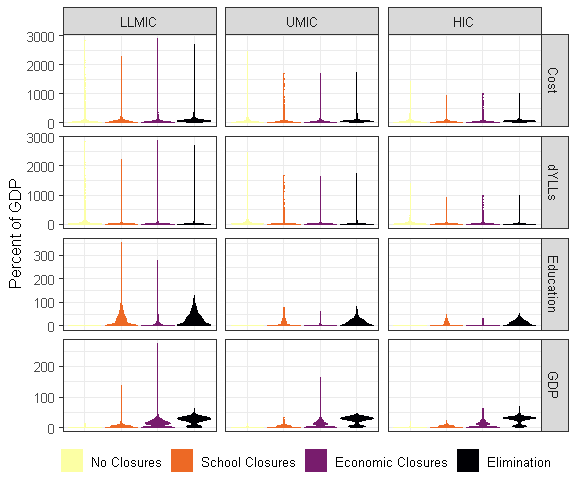

Figure 3.1: Model results for the 365-day SARS-X vaccine without the BPSV.

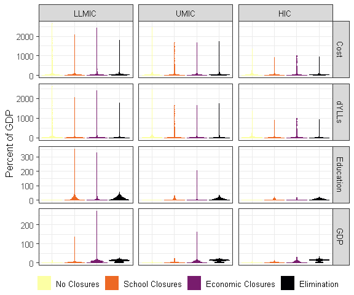

Figure 3.2: Model results for the 100-day SARS-X vaccine without the BPSV.

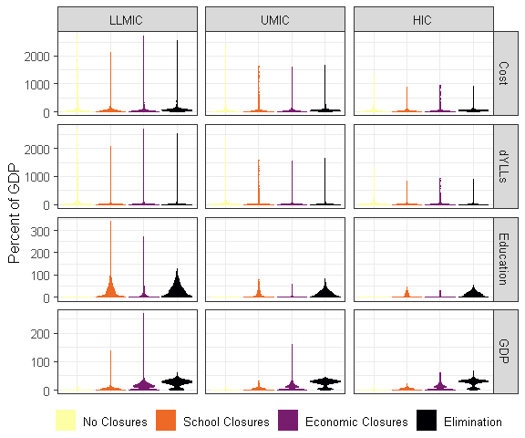

Figure 3.3: Model results for the 365-day SARS-X vaccine with the BPSV.

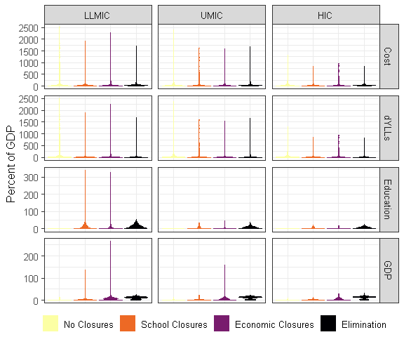

Figure 3.4: Model results for the 100-day SARS-X vaccine with the BPSV.

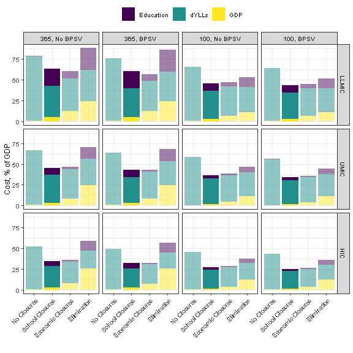

Figure 3.5: Expected values of model results.

## 3.2 Value of vaccination scenarios

Finally, note that there are samples with a negative value. These come from unlikely large exit waves that arise when all NPIs are suspended following completion of the vaccine rollout.

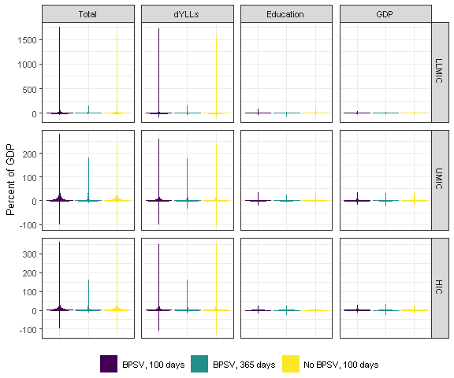

Figure 3.6: Model results for costs saved by 100-day and BPS vaccines.

Table 3.2: Value of vaccines as a percent of GDP: differences between BAU and scenarios. Mean values and 95% prediction intervals.

| Scenario | Income group | Total value | dYLLs | Education | GDP |
| --- | --- | --- | --- | --- | --- |
| 100 days, no BPSV | LLMIC | 0.3–9.3 | 0–3.5 | 0–0.3 | 0–2.2 |
| 100 days, no BPSV | UMIC | 0.4–7.3 | 0–3.1 | 0–0 | 0–2 |
| 100 days, no BPSV | HIC | 0.5–6.7 | 0–3.2 | 0–0 | 0–1.9 |
| 365 days, BPSV | LLMIC | 0.1–1.8 | 0.1–1.4 | 0–0 | 0–0 |
| 365 days, BPSV | UMIC | 0.1–1.8 | 0.1–1.6 | 0–0 | 0–0 |
| 365 days, BPSV | HIC | 0.1–1.9 | 0.1–1.7 | 0–0 | 0–0 |
| 100 days, BPSV | LLMIC | 0.7–10.6 | 0.1–4.7 | 0–0.5 | 0–2.2 |
| 100 days, BPSV | UMIC | 0.8–9 | 0.2–4.4 | 0–0.3 | 0–2 |
| 100 days, BPSV | HIC | 0.9–8.6 | 0.3–4.6 | 0–0 | 0–2 |

## 3.3 Other visualisations

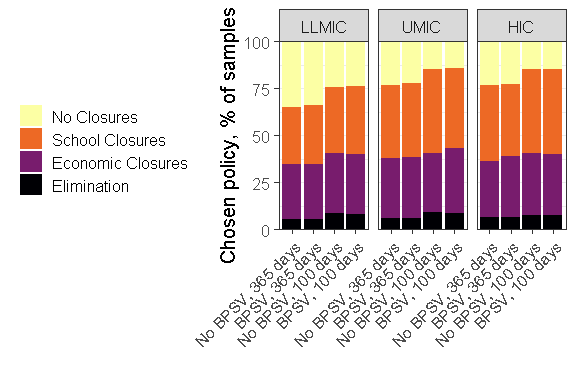

Figure 3.7: Frequency of mitigation policy choices.

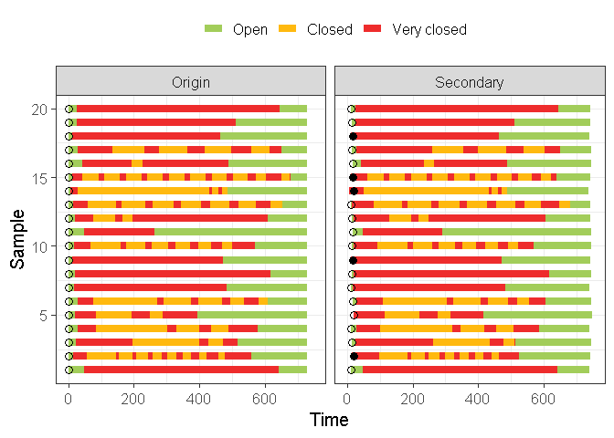

Figure 3.8: Closures for HICs under the Economic Closures policy.

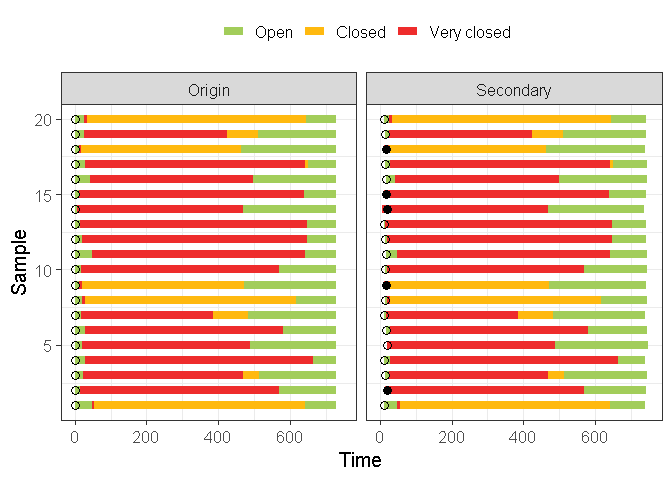

Figure 3.9: Closures for HICs under the Elimination policy. *Future development: find the most open configuration for “Closed” that will allow Rt to remain below 1.*

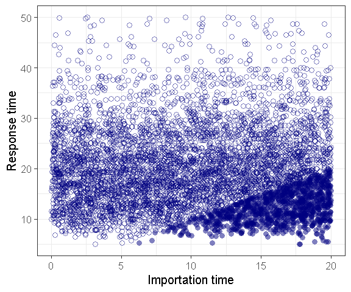

Figure 3.10: Secondary countries: importation time vs. response time. Where importation time is before response time, the epidemic unfolds as in the Origin country, but with an earlier response time. *Future development: there is not a qualitative difference between Origin and Secondary countries. We could therefore remove this label and vary the importation time from 0 to 20, to include the Origin feature. This would also allow for the possibility that a Secondary country with early importation detects, reports and responds earlier than the Origin country.*

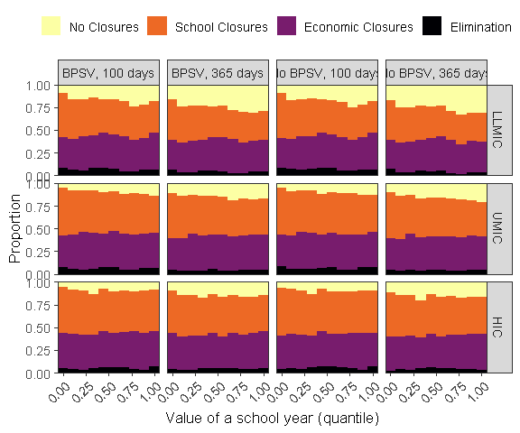

Figure 3.11: The relationship between policy choice and value of a school year.

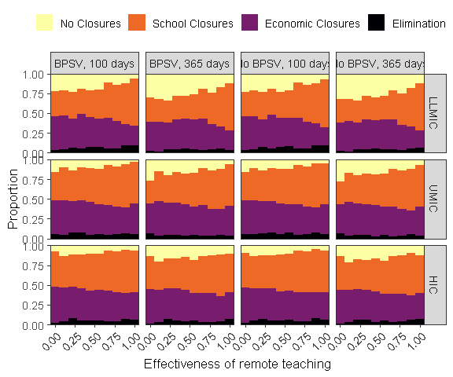

Figure 3.12: The relationship between policy choice and the effectiveness of remote teaching.

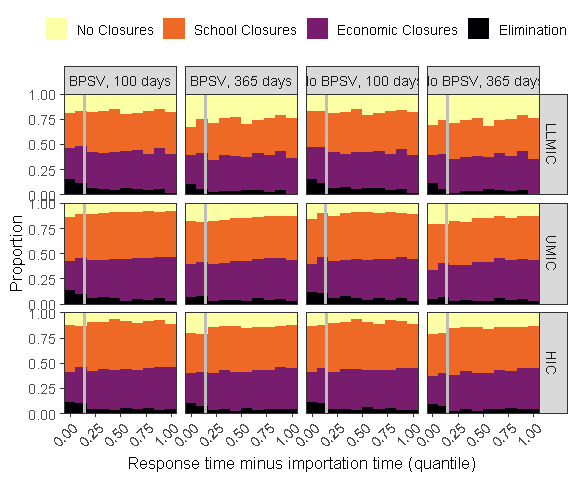

Figure 3.13: The relationship between policy choice and the duration between import time and response time.

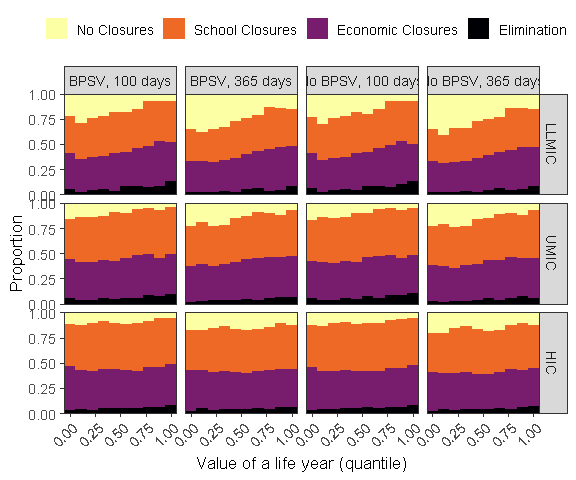

Figure 3.14: The relationship between policy choice and value of a life year.

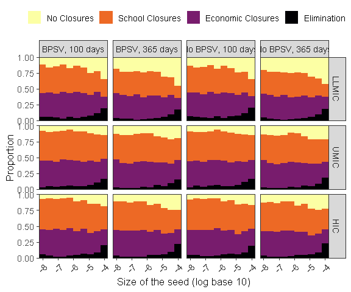

Figure 3.15: The relationship between policy choice and the size of the seed.

## 3.4 Value of information

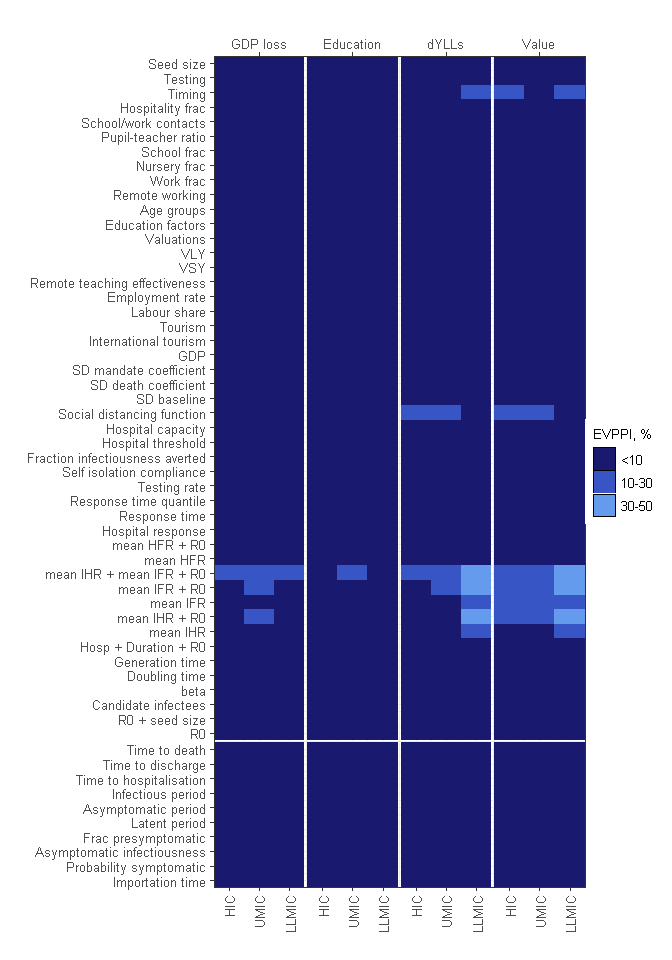

Figure 3.16: Value of information for 100-day vaccine value.

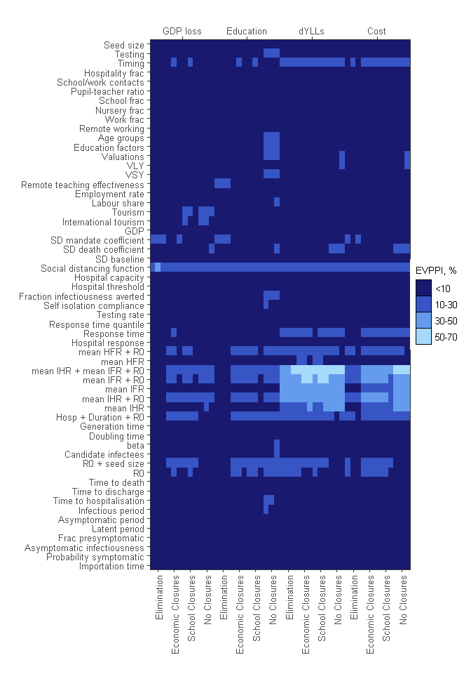

Figure 3.17: Value of information for BAU.

# 4 Conclusions

In parallel, we present a selection of other model parameters, including those related to demography (e.g. the fraction of the population who are of school age), to the economy (e.g. GDP), to the health system (e.g. hospital capacity), to the pandemic response (e.g. the rate of testing), and to the pathogen (e.g. the basic reproductive number, R$_0$). We found that these variables – in combinations up to four – account for much of the variability in outcomes.

## 4.1 The modelling framework

Ours is a mechanistic simulation model. The model encodes complex relationships between demographic, epidemic and economic variables. With simulation, it allows us to explore outcomes as consequences of inputs using information- and decision-theoretic methods. Modelling allows *in silico* experimentation, which is crucial for questions pertaining to rare events with small and confounded datasets, as cross-sectional country data are. The model allows us to ask questions about cause and effect that cannot be asked in reality and rarely can be inferred from observational data.

The challenge we face with modelling, then, is to be confident that our model mimics reality, or at least captures the elements with which we are concerned.

## 4.2 The economic model

We have used a simple economic model that allows us to estimate GDP loss in a year assuming that sector closures follow mandates. The mandates we use are schematic and representative of GVA profiles seen in different countries in 2020.

The economic model is static, and does not take into account any dynamics such as feedback, changes to demand, supply and supply chains, changes in international trade, or any macroeconomic factors. As such, to model longer-term economic impacts (apart from the impact of lost education) is beyond the scope of this model.

For example, Figure 4.1 shows the relationship between GDP loss in the first year (2020) and GDP loss in the second year (2021) following the outbreak of COVID-19. There is heterogeneity in losses in the first year, but also in whether or not the economy recovers in the second year, and to what extent. The recovery is arguably a more important phenomenon to capture than initial losses, and it is not something that can be captured by our economic model. However, a model of recovery / future losses would include initial loss as an input, which our model could provide.

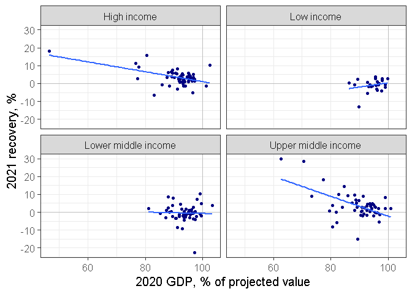

Figure 4.1: GDP loss and recovery. On the x axis is the GDP of 2020 relative to its 2019 projected value (IMF). On the y axis is 2021 GDP relative to its 2019 projected value relative to the same value for 2020 (ratio of ratios). x values below 100 represent a loss in the year 2020. y values above 0 represent recovery (i.e. growth exceeded what was expected in 2019); y values equal to zero represent a fixed level of loss; y values less than zero represent increasing loss.

# 5 References

Haw, David, Giovanni Forchini, Patrick Doohan, Paula Christen, Matteo Pianella, Rob Johnson, Sumali Bajaj, et al. 2022. “Optimizing social and economic activity while containing SARS-CoV-2 transmission using DAEDALUS.” *Nature Computational Science* 2: 223–33. https://doi.org/10.25561/83928.

Jackson, Christopher, Robert Johnson, Audrey De Nazelle, Rahul Goel, Thiago Hérick De Sá, Marko Tainio, and James Woodcock. 2021. “A guide to value of information methods for prioritising research in health impact modelling.” *Epidemiologic Methods* 10 (1): 1–22. https://doi.org/10.1515/em-2021-0012.

Jarvis, Christopher I, Pietro Coletti, Jantien A Backer, James D Munday, Christel Faes, Philippe Beutels, Christian L. Althaus, et al. 2023. “Social contact patterns following the COVID-19 pandemic: a snapshot of post-pandemic behaviour from the CoMix study.” *MedRxiv*.

Psacharopoulos, George, Victoria; Collis, and Patrinos. 2021. “The COVID-19 Cost of School Closures in Earnings and Income across the World.” *Comparative Education Review* 65 (2).

Robinson, Lisa A., James K. Hammitt, and Lucy O’Keeffe. 2019. “Valuing mortality risk reductions in global benefit-cost analysis.” *Journal of Benefit-Cost Analysis* 10: 15–50. https://doi.org/10.1017/bca.2018.26.

Walker, Patrick G. T., Charles Whittaker, Oliver J. Watson, Marc Baguelin, Peter Winskill, Arran Hamlet, Bimandra A. Djafaara, et al. 2020. “The impact of COVID-19 and strategies for mitigation and suppression in low- and middle-income countries.” *Science* 369 (6502): 413–22. https://doi.org/10.1126/science.abc0035.